# IBM HR Employee Attrition

## Building the model

- 2 different models:
  - Logistic Regression
  - K-Nearest Neighbors (K-NN)

### Logistic Regression

- Logistic Regression is a supervised learning algorithm, generally used for binary classification problems, i.e., where the dependent variable is categorical and has only two possible values. In logistic regression, we use the sigmoid function to calculate the probability of an event

```python
# Fitting the logistic regression model
lg = LogisticRegression()

# Use train data
lg.fit(x_train, y_train)
```

```
LogisticRegression()
```

Checking the model performance

```
              precision    recall  f1-score   support

           0       0.91      0.98      0.94       863
           1       0.81      0.52      0.64       166

    accuracy                           0.90      1029
   macro avg       0.86      0.75      0.79      1029
weighted avg       0.90      0.90      0.89      1029
```

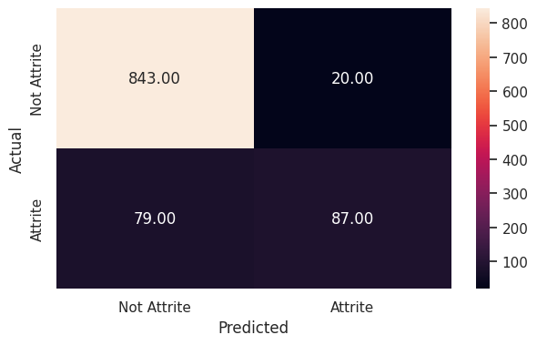

```python
# Checking the performance on the training data
y_pred_train = lg.predict(x_train)

metrics_score(y_train, y_pred_train)
```

```
              precision    recall  f1-score   support

           0       0.92      0.95      0.93       370
           1       0.69      0.56      0.62        71

    accuracy                           0.89       441
   macro avg       0.80      0.76      0.78       441
weighted avg       0.88      0.89      0.88       441
```

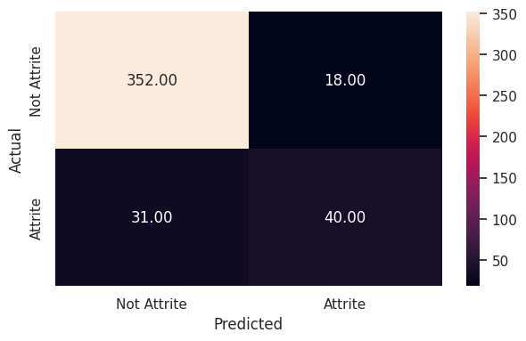

```python
# Checking the performance on the test dataset
y_pred_test = lg.predict(x_test)

metrics_score(y_test, y_pred_test)
```

Logistic Regression Model – Train vs Test Comparison

| Metric | Train Set | Test Set |
| --- | --- | --- |
| Accuracy | 90% | 89% |
| Precision (Attrite) | 0.81 | 0.69 |
| **Recall (Attrite)** | **0.52** | **0.56** |
| F1-score (Attrite) | 0.64 | 0.62 |
| Macro Avg F1 | 0.79 | 0.78 |
| Weighted Avg F1 | 0.89 | 0.88 |

Observations

- **Consistent Accuracy**: The model performs similarly on both train (90%) and test (89%) sets, suggesting minimal overfitting.
- **Precision Drop**: Precision for predicting "Attrite" dropped from 0.81 (train) to 0.69 (test), indicating more false positives in test predictions.
- **Recall (Attrite)**:
  - Remains relatively **consistent** across sets (52% train, 56% test)
  - Still **low overall**, meaning the model misses many actual attrition cases
  - **Critical metric** for this project, since identifying who will leave is the goal
- **F1-Score Balanced**: The F1-score for attrition is reasonable (~0.62 test), showing balanced precision/recall.
- **Confusion Matrix Insight**: Majority class (Not Attrite) dominates, but the model does catch some attrition cases correctly on both datasets.

Let's check the coefficients and find which variables are leading to attrition and which can help to reduce the attrition.

- Identify the different factors that drive attritio

```python
# Printing the coefficients of logistic regression
cols = X.columns

coef_lg = lg.coef_

pd.DataFrame(coef_lg,columns = cols).T.sort_values(by = 0, ascending = False)
```

|  | 0 |
| --- | --- |
| JobRole_Human Resources | 0.668080 |
| Department_Research & Development | 0.583120 |
| Department_Sales | 0.508962 |
| NumCompaniesWorked | 0.201114 |
| MonthlyRate | 0.191719 |
| JobRole_Sales Executive | 0.191430 |
| DistanceFromHome | 0.188664 |
| OverTime | 0.187350 |
| BusinessTravel_Travel_Frequently | 0.186806 |
| JobRole_Sales Representative | 0.160719 |
| YearsAtCompany | 0.159287 |
| TotalWorkingYears | 0.138317 |
| MaritalStatus_Single | 0.128887 |
| HourlyRate | 0.116663 |
| YearsSinceLastPromotion | 0.098051 |
| BusinessTravel_Travel_Rarely | 0.081989 |
| Education_5 | 0.068811 |
| EducationField_Technical Degree | 0.064463 |
| MaritalStatus_Married | 0.050447 |
| Gender_Male | 0.050227 |
| JobRole_Laboratory Technician | 0.049650 |
| JobRole_Manufacturing Director | 0.049025 |
| JobLevel_5 | 0.043641 |
| Education_4 | 0.042712 |
| Education_3 | 0.031028 |
| Education_2 | 0.026473 |
| EducationField_Marketing | 0.006124 |
| PerformanceRating | -0.015083 |
| EducationField_Other | -0.017131 |
| JobRole_Manager | -0.020784 |
| JobLevel_3 | -0.025064 |
| EducationField_Medical | -0.027602 |
| JobRole_Research Scientist | -0.029413 |
| PercentSalaryHike | -0.038104 |
| EducationField_Life Sciences | -0.060787 |
| StockOptionLevel | -0.061669 |
| RelationshipSatisfaction | -0.085931 |
| JobLevel_4 | -0.092284 |
| WorkLifeBalance | -0.095117 |
| DailyRate | -0.099027 |
| EnvironmentSatisfaction_3 | -0.118339 |
| EnvironmentSatisfaction_2 | -0.122646 |
| JobLevel_2 | -0.127181 |
| YearsInCurrentRole | -0.138188 |
| EnvironmentSatisfaction_4 | -0.144436 |
| JobInvolvement_2 | -0.145179 |
| JobSatisfaction | -0.151707 |
| JobInvolvement_3 | -0.163991 |
| YearsWithCurrManager | -0.182585 |
| JobInvolvement_4 | -0.208509 |
| TrainingTimesLastYear | -0.221600 |
| Age | -0.339546 |
| JobRole_Research Director | -0.353058 |
| MonthlyIncome | -0.425236 |

List of most important features sorted (above)

- The higher the value, the stronger the contribution to predicting Attrition = Yes.

A positive coefficient (0.668) means:

- Employees in Human Resources roles are more likely to attrite (leave the company) compared to the baseline job role.

Odds ratios for each feature

- Odds > 1 → higher chance of attrition
- Odds < 1 → lower chance of attrition

The coefficients of the logistic regression model give us the log of odds, which is hard to interpret in the real world. We can convert the log of odds into odds by taking its exponential.

```python
odds = np.exp(lg.coef_[0]) # Finding the odds
  #  odds ratios for each feature

# Adding the odds to a DataFrame and sorting the values
pd.DataFrame(odds, x_train.columns, columns = ['odds']).sort_values(by = 'odds', ascending = False)
```

|  | odds |
| --- | --- |
| JobRole_Human Resources | 1.950488 |
| Department_Research & Development | 1.791619 |
| Department_Sales | 1.663564 |
| NumCompaniesWorked | 1.222765 |
| MonthlyRate | 1.211330 |
| JobRole_Sales Executive | 1.210980 |
| DistanceFromHome | 1.207635 |
| OverTime | 1.206049 |
| BusinessTravel_Travel_Frequently | 1.205393 |
| JobRole_Sales Representative | 1.174355 |
| YearsAtCompany | 1.172675 |
| TotalWorkingYears | 1.148340 |
| MaritalStatus_Single | 1.137562 |
| HourlyRate | 1.123741 |
| YearsSinceLastPromotion | 1.103019 |
| BusinessTravel_Travel_Rarely | 1.085444 |
| Education_5 | 1.071234 |
| EducationField_Technical Degree | 1.066586 |
| MaritalStatus_Married | 1.051741 |
| Gender_Male | 1.051510 |
| JobRole_Laboratory Technician | 1.050903 |
| JobRole_Manufacturing Director | 1.050247 |
| JobLevel_5 | 1.044607 |
| Education_4 | 1.043637 |
| Education_3 | 1.031514 |
| Education_2 | 1.026826 |
| EducationField_Marketing | 1.006143 |
| PerformanceRating | 0.985030 |
| EducationField_Other | 0.983015 |
| JobRole_Manager | 0.979430 |
| JobLevel_3 | 0.975247 |
| EducationField_Medical | 0.972775 |
| JobRole_Research Scientist | 0.971015 |
| PercentSalaryHike | 0.962613 |
| EducationField_Life Sciences | 0.941024 |
| StockOptionLevel | 0.940194 |
| RelationshipSatisfaction | 0.917658 |
| JobLevel_4 | 0.911846 |
| WorkLifeBalance | 0.909267 |
| DailyRate | 0.905718 |
| EnvironmentSatisfaction_3 | 0.888395 |
| EnvironmentSatisfaction_2 | 0.884577 |
| JobLevel_2 | 0.880574 |
| YearsInCurrentRole | 0.870935 |
| EnvironmentSatisfaction_4 | 0.865511 |
| JobInvolvement_2 | 0.864867 |
| JobSatisfaction | 0.859240 |
| JobInvolvement_3 | 0.848750 |
| YearsWithCurrManager | 0.833114 |
| JobInvolvement_4 | 0.811794 |
| TrainingTimesLastYear | 0.801236 |
| Age | 0.712093 |
| JobRole_Research Director | 0.702537 |
| MonthlyIncome | 0.653616 |

Logistic Regression – Odds Ratio Observations